# *Demonstration of the Data Science Pipleine Using Twitch Broadcaster Analytics*

Author: Eva Josephine Palmhede

## Introduction

Twitch.tv is an online platform that hosts millions of broadcasters who stream content to viewers every day. Many of these broadcasters create content on Twitch for a living; they get money through ad revenue, donations, and Twitch's subscription service. All three of these rely on the broadcaster maintaining a high view count during their streams. If there are no viewers, there are no people to watch adds, dontate, or subscribe.

For Twitch streamers, analytics are everything. When income is directly reliant on your popularity and ability to connect with an audience, knowing the patterns of viewership and exposure is important.

Based on my initial knowledge of the relationship between these stats, I have two questions I would like to explore. After the exploratory data analysis I will revisit them and make any edits I think are appropriate before I start testing any hypothesis.

```
Questions:
Does a high average view count translate to a higher ratio of new viewers and followers?
Does a high follower count translate to a high average view count?
```

## Data Collection and Parsing

I will use several libraries throughout this tutorial. At the end of this tutorial you will find links to the documentation for each of them so that you may explore them on your own.

```python
import pandas as pd
import seaborn as sns
import matplotlib.pyplot as plt
from scipy import stats
```

Pandas is a great library for data organizing and parsing. I use it to read the data into a table and then display the table to make sure it was read correctly.

```python
# Read the data into a dataframe
df=pd.read_csv('JosephinePalmhede.github.io/twitchdata-update.csv')
# Display the first five entries in the table
df.head()
```

|  | Channel | Watch time(Minutes) | Stream time(minutes) | Peak viewers | Average viewers | Followers | Followers gained | Views gained | Partnered | Mature | Language |
| --- | --- | --- | --- | --- | --- | --- | --- | --- | --- | --- | --- |
| 0 | xQcOW | 6196161750 | 215250 | 222720 | 27716 | 3246298 | 1734810 | 93036735 | True | False | English |
| 1 | summit1g | 6091677300 | 211845 | 310998 | 25610 | 5310163 | 1370184 | 89705964 | True | False | English |
| 2 | Gaules | 5644590915 | 515280 | 387315 | 10976 | 1767635 | 1023779 | 102611607 | True | True | Portuguese |
| 3 | ESL_CSGO | 3970318140 | 517740 | 300575 | 7714 | 3944850 | 703986 | 106546942 | True | False | English |
| 4 | Tfue | 3671000070 | 123660 | 285644 | 29602 | 8938903 | 2068424 | 78998587 | True | False | English |

Let's take some time to understand this data so that we can think about how the stats might interact. Keep in mind that these stats are collected over one year and not over the channel's lifetime.

Watch time on twitch means the number of minutes summed over all viewers that people have watched a stream. Stream time is the total number of minutes a channel has spent live over the past year. Peak viewers and average viewers are the highest number of viewers you've had and the number of viewers you average over all streams, respectively. Views gained are the number of *new* viewers a stream has gotten. Followers and viewers gained are the number of followers or viewers gained by a streamer in the past year.

The last three columns, partnered, mature, and language, are a little different. Partnered on twitch means that viewers are able to subscribe to the channel and the streamer gets a paycheck from twitch based on the number of subscribers they have. Mature means the stream is marked for an audience that is 18+. Language is the primary language the streamer speaks in and the chat speaks in.

## Data Management and Representation

```python
df.describe()
```

|  | Watch time(Minutes) | Stream time(minutes) | Peak viewers | Average viewers | Followers | Followers gained | Views gained |
| --- | --- | --- | --- | --- | --- | --- | --- |
| count | 1.000000e+03 | 1000.000000 | 1000.000000 | 1000.000000 | 1.000000e+03 | 1.000000e+03 | 1.000000e+03 |
| mean | 4.184279e+08 | 120515.160000 | 37065.051000 | 4781.040000 | 5.700541e+05 | 2.055185e+05 | 1.166817e+07 |
| std | 5.496355e+08 | 85376.201364 | 60314.307686 | 8453.684965 | 8.044134e+05 | 3.399137e+05 | 2.490572e+07 |
| min | 1.221928e+08 | 3465.000000 | 496.000000 | 235.000000 | 3.660000e+03 | -1.577200e+04 | 1.757880e+05 |
| 25% | 1.631899e+08 | 73758.750000 | 9113.750000 | 1457.750000 | 1.705462e+05 | 4.375825e+04 | 3.880602e+06 |
| 50% | 2.349908e+08 | 108240.000000 | 16676.000000 | 2425.000000 | 3.180630e+05 | 9.835200e+04 | 6.456324e+06 |
| 75% | 4.337399e+08 | 141843.750000 | 37569.750000 | 4786.250000 | 6.243322e+05 | 2.361308e+05 | 1.219676e+07 |
| max | 6.196162e+09 | 521445.000000 | 639375.000000 | 147643.000000 | 8.938903e+06 | 3.966525e+06 | 6.701375e+08 |

```python
df.corr()
```

|  | Watch time(Minutes) | Stream time(minutes) | Peak viewers | Average viewers | Followers | Followers gained | Views gained | Partnered | Mature |
| --- | --- | --- | --- | --- | --- | --- | --- | --- | --- |
| Watch time(Minutes) | 1.000000 | 0.150588 | 0.582797 | 0.476165 | 0.620234 | 0.514648 | 0.529862 | 0.038258 | -0.043197 |
| Stream time(minutes) | 0.150588 | 1.000000 | -0.119540 | -0.249248 | -0.091299 | -0.158165 | 0.064370 | -0.007073 | 0.044978 |
| Peak viewers | 0.582797 | -0.119540 | 1.000000 | 0.682637 | 0.532529 | 0.470415 | 0.298063 | 0.028112 | -0.082750 |
| Average viewers | 0.476165 | -0.249248 | 0.682637 | 1.000000 | 0.428303 | 0.420097 | 0.250349 | -0.008983 | -0.081648 |
| Followers | 0.620234 | -0.091299 | 0.532529 | 0.428303 | 1.000000 | 0.715618 | 0.276467 | 0.044418 | -0.088521 |
| Followers gained | 0.514648 | -0.158165 | 0.470415 | 0.420097 | 0.715618 | 1.000000 | 0.244297 | 0.027465 | -0.093001 |
| Views gained | 0.529862 | 0.064370 | 0.298063 | 0.250349 | 0.276467 | 0.244297 | 1.000000 | -0.035313 | -0.088119 |
| Partnered | 0.038258 | -0.007073 | 0.028112 | -0.008983 | 0.044418 | 0.027465 | -0.035313 | 1.000000 | 0.000972 |
| Mature | -0.043197 | 0.044978 | -0.082750 | -0.081648 | -0.088521 | -0.093001 | -0.088119 | 0.000972 | 1.000000 |

This table is very interesting to us. We can see the correlation between followers and average view count as well as correlation between average view count and new views & follows. This gives us information on whether or not we can expect our hypothesis will hold.

### Missing Data

Lucky for us, this table has no missing data. For the purposes of this tutorial though I will go through a simple way to comb data and deal with missing values using Pandas Dataframe.

```python
# Loop through all rows in the table. Use pattern matching to separate the index from the row.
for index, row in df.iterrows():
    # Loop through the columns in the row
    for i in range(len(row)):
        # Check for missing data. This line will be different depending on how your missing data is represented.
        if row[i] == None:
            # Convert missing data to pandas' NaN type
            row[i] = np.nan
```

### Pruning Data

Lastly, I am going to reduce the data to only the top 100 streamers based on number of followers. I choose 100 because any more than that and the data starts to be heavily weighed down to the lower end.

```python
# Pull the top 100 rows from the table based on the followers column
top_100 = df.nlargest(100, 'Followers')
top_100.head()
```

|  | Channel | Watch time(Minutes) | Stream time(minutes) | Peak viewers | Average viewers | Followers | Followers gained | Views gained | Partnered | Mature | Language |
| --- | --- | --- | --- | --- | --- | --- | --- | --- | --- | --- | --- |
| 4 | Tfue | 3671000070 | 123660 | 285644 | 29602 | 8938903 | 2068424 | 78998587 | True | False | English |
| 96 | shroud | 888505170 | 30240 | 471281 | 29612 | 7744066 | 833587 | 30621257 | True | False | English |
| 35 | Myth | 1479214575 | 134760 | 122552 | 9396 | 6726893 | 1421811 | 37384058 | True | False | English |
| 13 | Rubius | 2588632635 | 58275 | 240096 | 42948 | 5751354 | 3820532 | 58599449 | True | False | Spanish |
| 90 | pokimane | 964334055 | 56505 | 112160 | 16026 | 5367605 | 2085831 | 45579002 | True | False | English |

## Exploratory Data Analysis

In this section I am first going to create a heatmap as a visual for the correlation between broadcaster's statistics. Then I will create three plots to explore my hypotheses. The first will show compare a stream's average viewers to the broadcaster's average followers. The idea behind this one is that more followers should equate to more viewers, since more people are being notified when the broadcaster is live. The second will compare a stream's average viewers versus the broadcaster's followers gained. In theory, more viewers should lead to more new people clicking the follow button on the stream. The third and last plot will compare a stream's average viewers versus its average views gained. More viewers should place the stream higher on the discover list, leading to more new people finding the stream.

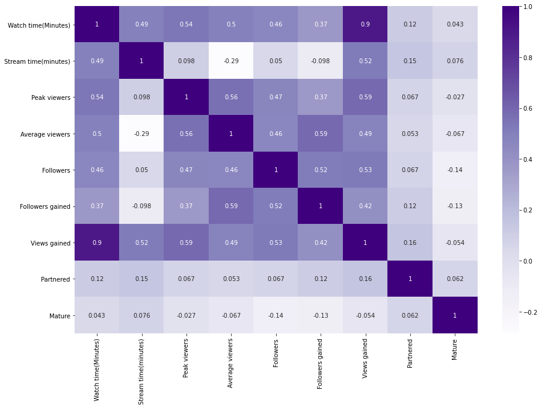

```python
# Make the plot bigger for better readability
plt.figure(figsize=(15,10))
# Construct the plot using Seaborne's heatmap function
sns.heatmap(top_100.corr(), annot=True, cmap='Purples')
plt.show()
```

[figure not shown]

```python
# Plotting Average viewers versus Followers
# Make the plot larger so it is easier to read
plt.rcParams["figure.figsize"] = (15,10)
# Plot the data
plt.scatter(top_100['Average viewers'], top_100['Followers'], c='Purple')
# Edit the plot metadata
plt.title('Average Viewers Versus Followers')
plt.xlabel('Average viewers')
plt.ylabel('Followers (in millions)')
plt.show()
```

This data is pretty scattered but we can still see a cluster in the lower left.

[figure not shown]

```python
# Make the plot larger so it is easier to read
plt.rcParams["figure.figsize"] = (15,10)
# Plot the data
plt.scatter(top_100['Average viewers'], top_100['Followers gained'], c='Purple')
# Edit the plot metadata
plt.title('Average viewers Versus Followers Gained')
plt.xlabel('Average viewers')
plt.ylabel('Followers gained (in millions)')
plt.show()
```

Same with this plot, there is a cluster in the lower left but as we move away from that area the data is more scattered.

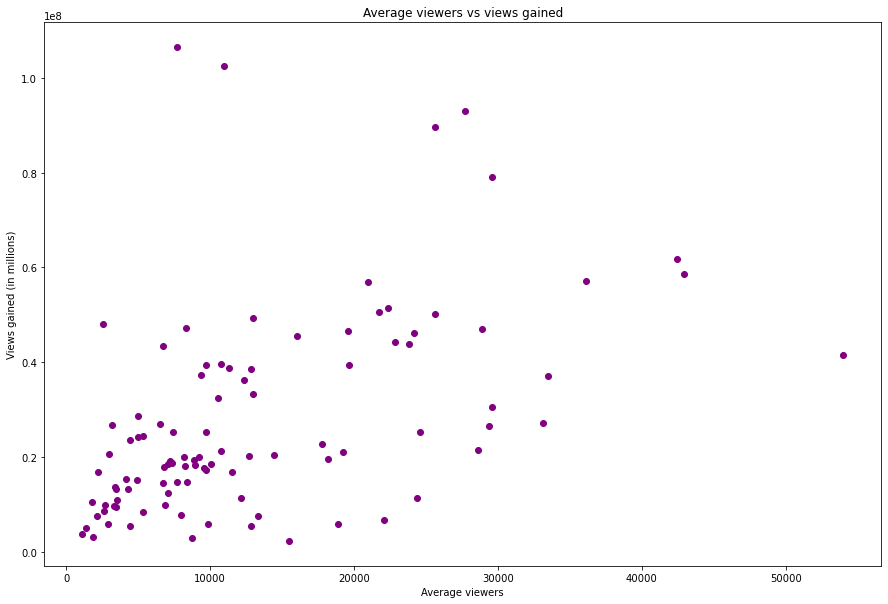

```python
# Make the plot larger so it is easier to read
plt.rcParams["figure.figsize"] = (15,10)
# Plot the data
plt.scatter(top_100['Average viewers'], top_100['Views gained'], c='Purple')
# Edit the plot metadata
plt.title('Average viewers vs views gained')
plt.xlabel('Average viewers')
plt.ylabel('Views gained (in millions)')
plt.show()
```

This data has the clearest trend line going through it.

Next I will fit a linear regression to these plots and see how it turns out. But before that I will completely form my hypotheses and null hypotheses. The questions I started with were: Does a high follower count translate to a high average view count? Does a high average view count translate to a higher ratio of new viewers and followers?

My first hypothesis is that a high follower count translates to a high average view count. And I have the same null hypothesis that there is no relationship between the two statistics.

My second hypothesis is that a high average view count translates to a higher ratio of new viewers and followers. My null hypotheis is that there is no relationship between the two statistics.

## Hypothesis Testing

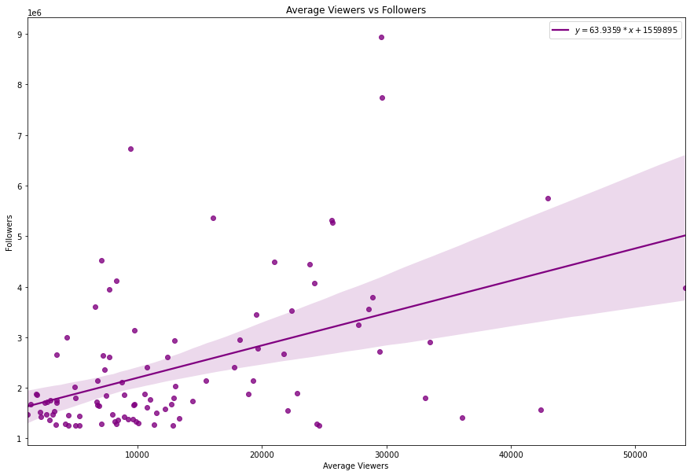

```python
# Calculate a linear regression and pull out the slope and intercept
slope, intercept, rvalue, pvalue, stderr = stats.linregress(top_100['Average viewers'], top_100['Followers'])
# Make the plot larger
fig, ax = plt.subplots(figsize=(15,10))
# Construct the plot, inserting the slope and intercept as an equation for the line in the legend
sns.regplot(top_100['Average viewers'], top_100['Followers'], color='Purple', line_kws={'label':'$y=%3.7s*x+%3.7s$'%(slope, intercept)})
plt.legend()
# Edit the plot metadata
plt.title("Average Viewers vs Followers")
plt.xlabel("Average Viewers")
plt.ylabel("Followers")
```

This does not look to me like there is actually a linear relationship between the two stats. The data is too scattered for me to confidently say there is. But if I were to plot the entire data set, we would see that there is a huge cluster in the bottom left of the plot and only a few breakout points in the rest of the plot. So maybe the correct thing to say is that a *lower* number of followers will correspond with a *low* number of viewers and that it is harder to make a statement about broadcasters with a lot of followers.

Just to illustrate this, I will create the same plot using the entire set of data:

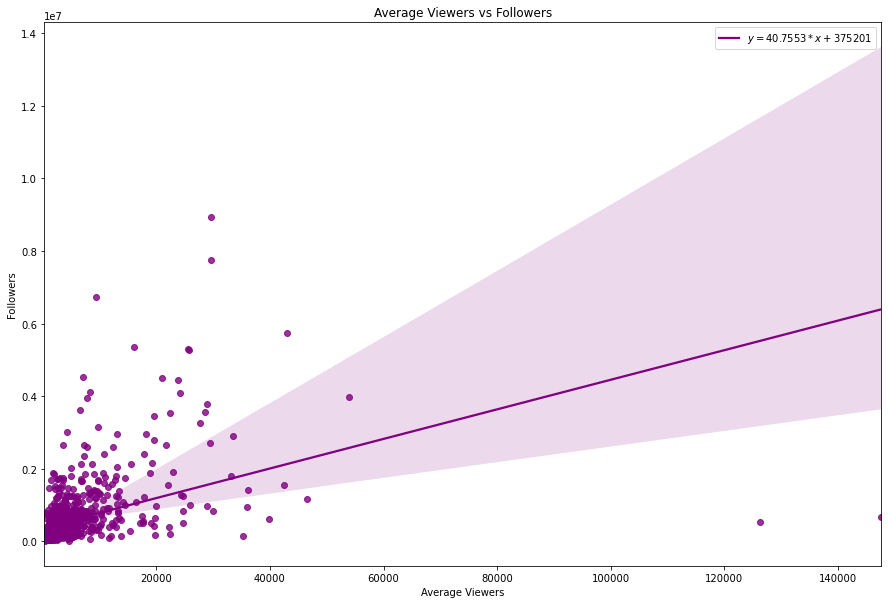

```python
# Calculate a linear regression and pull out the slope and intercept
slope, intercept, rvalue, pvalue, stderr = stats.linregress(df['Average viewers'], df['Followers'])
# Make the plot larger
fig, ax = plt.subplots(figsize=(15,10))
# Construct the plot, inserting the slope and intercept as an equation for the line in the legend
sns.regplot(df['Average viewers'], df['Followers'], color='Purple', line_kws={'label':'$y=%3.7s*x+%3.7s$'%(slope, intercept)})
plt.legend()
# Edit the plot metadata
plt.title("Average Viewers vs Followers")
plt.xlabel("Average Viewers")
plt.ylabel("Followers")
```

Interestingly, there are two points on this graph that are extremely far to the right (high average viewers) but both are very low in followers. This leads me to reject my hypothesis that a high follower count translates to a high average view count. I do not, though, accept the null hypothesis that there is no relationship between the two statistics because of the cluster of dots in the bottom left corner. The cluster suggests that, for smaller broadcasters, there is a relationship between the two statistics.

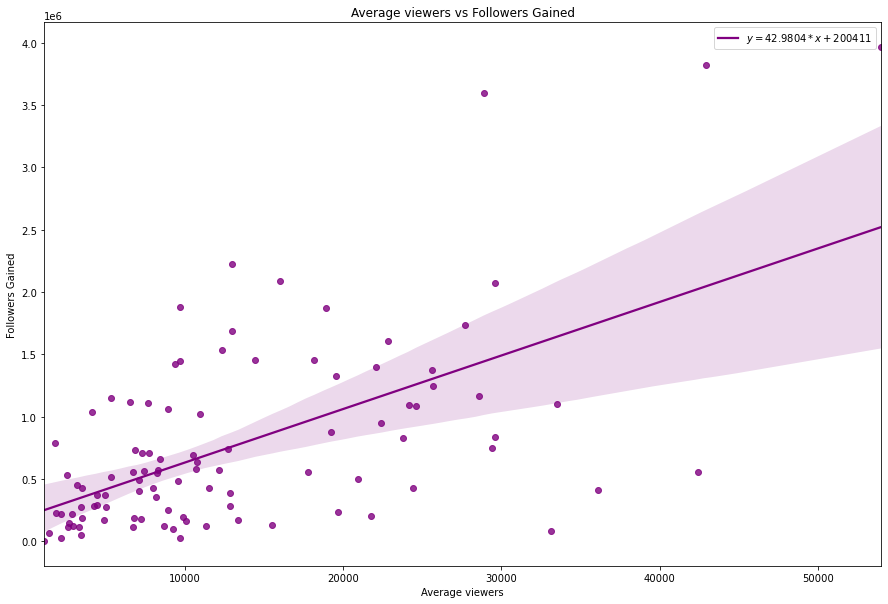

```python
# Calculate a linear regression and pull out the slope and intercept
slope, intercept, rvalue, pvalue, stderr = stats.linregress(top_100['Average viewers'], top_100['Followers gained'])
# Make the plot larger
fig, ax = plt.subplots(figsize=(15,10))
# Construct the plot, inserting the slope and intercept as an equation for the line in the legend
sns.regplot(top_100['Average viewers'], top_100['Followers gained'], color='Purple', line_kws={'label':'$y=%3.7s*x+%3.7s$'%(slope, intercept)})
plt.legend()
# Edit the plot metadata
plt.title("Average viewers vs Followers Gained")
plt.xlabel("Average viewers")
plt.ylabel("Followers Gained")
```

This plot looks a lot like the first one, but this one has fewer extreme outliers when the last one had a significant number of them. In this case, since there are fewer extreme outliers, I will accept my hypothesis that a high average view count translates to a high number of followers gained.

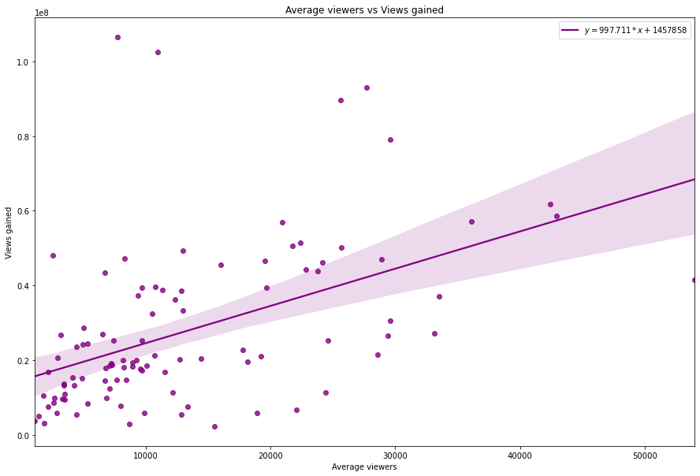

```python
# Calculate a linear regression and pull out the slope and intercept
slope, intercept, rvalue, pvalue, stderr = stats.linregress(top_100['Average viewers'], top_100['Views gained'])
# Make the plot larger
fig, ax = plt.subplots(figsize=(15,10))
# Construct the plot, inserting the slope and intercept as an equation for the line in the legend
sns.regplot(top_100['Average viewers'], top_100['Views gained'], color='Purple', line_kws={'label':'$y=%3.7s*x+%3.7s$'%(slope, intercept)})
plt.legend()
# Edit the plot metadata
plt.title("Average viewers vs Views gained")
plt.xlabel("Average viewers")
plt.ylabel("Views gained")
```

## Communication of Insights Attained

A review of the data science process:

1. Scrape the data
2. Format and tidy the data
3. Explore the data and develop a hypothesis
4. Test your hypothesis
5. Draw conclusions

Now that we have gone through the steps of the datascience pipeline, I will conclude with a summary of what we analyzed and learned.

My two hypotheses were that a high follower count translates to a high average view count and my second hypothesis was that a high average view count translates to a higher ratio of new viewers and followers. What I learned was that it is hard to make conclusions like that about the top 100 streamers on twitch, perhaps because they are too large for general trends like that to affect them. What I was able to say was that a low number of followers correlates to a lower average number of viewers. I also concluded that a high average view count will translate to both a higher number of followers gained and a higher number of viewers gained. I attribute this to the method twitch uses to push streams, putting the ones with the most views at the top.

## Libraries and External Links to Resources

Data obtained from https://www.kaggle.com/aayushmishra1512/twitchdata

Pandas: https://pandas.pydata.org/

Seaborn: https://seaborn.pydata.org/

Matplotlib: https://matplotlib.org/

Scipy Stats: https://docs.scipy.org/doc/scipy/reference/stats.html